# Project: Investigate a Dataset - No Show Appointments

- Introduction
- Data Wrangling
- Exploratory Data Analysis
- Conclusions

## Introduction

#### This dataset collects information from 100k medical appointments in Brazil and is focused on the question of whether or not patients show up for their appointment. Some of the columns are;

#### 'PatientId': uniquely identifies the each Patients

#### 'AppointmentID': Unique identifier for appointments

#### 'Gender': Indicates the whether the patient is a Male or Female

#### ‘ScheduledDay’: tells us on what day the patient set up their appointment.

#### ‘Neighborhood’: indicates the location of the hospital.

#### ‘Scholarship’ : indicates whether or not the patient is enrolled in Brasilian welfare program Bolsa Família.

#### 'No-Show': shows Patients that showed the appointment respone. i.e ‘No’ if the patient showed up to their appointment, and ‘Yes’ if they did not show up.

#### 'Scholarship', 'Hipertension', 'Diabetes', 'Alcoholism' and 'Handcap': Shows whether the patients have these illness or not.

## Questions for Analysis

#### What Gender and Age Group has the highest number of Patients?

#### How many patients showed up for their appointments compared to those who failed to show up?

#### What Gender of the patients showed up for appointment the most?

#### What age category showed up the most for their appointments?

#### How many Patients got enrolled in the government scholarship showed up for their appointments?

#### How many Patients who got SMS reminder message showed up for their appointments compared to those who did not get the reminder?

#### How many of the patients who showed up for their appointments suffer from Hipertension, Diabetes and Alcoholism?

```python
import numpy as np
import pandas as pd
import matplotlib.pyplot as plt
import seaborn as sns
% matplotlib inline
```

```python
# Upgrade pandas to use dataframe.explode() function.

!pip install --upgrade pandas==0.25.0
```

## Data Wrangling

```python
#To view few rows in the data set

df = pd.read_csv('noshowappointments_data.csv')
df.head()
```

|  | PatientId | AppointmentID | Gender | ScheduledDay | AppointmentDay | Age | Neighbourhood | Scholarship | Hipertension | Diabetes | Alcoholism | Handcap | SMS_received | No-show |
| --- | --- | --- | --- | --- | --- | --- | --- | --- | --- | --- | --- | --- | --- | --- |
| 0 | 2.987250e+13 | 5642903 | F | 2016-04-29T18:38:08Z | 2016-04-29T00:00:00Z | 62 | JARDIM DA PENHA | 0 | 1 | 0 | 0 | 0 | 0 | No |
| 1 | 5.589978e+14 | 5642503 | M | 2016-04-29T16:08:27Z | 2016-04-29T00:00:00Z | 56 | JARDIM DA PENHA | 0 | 0 | 0 | 0 | 0 | 0 | No |
| 2 | 4.262962e+12 | 5642549 | F | 2016-04-29T16:19:04Z | 2016-04-29T00:00:00Z | 62 | MATA DA PRAIA | 0 | 0 | 0 | 0 | 0 | 0 | No |
| 3 | 8.679512e+11 | 5642828 | F | 2016-04-29T17:29:31Z | 2016-04-29T00:00:00Z | 8 | PONTAL DE CAMBURI | 0 | 0 | 0 | 0 | 0 | 0 | No |
| 4 | 8.841186e+12 | 5642494 | F | 2016-04-29T16:07:23Z | 2016-04-29T00:00:00Z | 56 | JARDIM DA PENHA | 0 | 1 | 1 | 0 | 0 | 0 | No |

```python
#To check for total number of Rows and Columns

df.shape
```

```
(110527, 14)
```

There are total of 110,527 rows and 14 columns in the data set

```python
#To show the data types

df.dtypes
```

```
PatientId         float64
AppointmentID       int64
Gender             object
ScheduledDay       object
AppointmentDay     object
Age                 int64
Neighbourhood      object
Scholarship         int64
Hipertension        int64
Diabetes            int64
Alcoholism          int64
Handcap             int64
SMS_received        int64
No-show            object
dtype: object
```

#### 'ScheduledDay' and 'AppointmentDay' datatype needs to be changed from 'object' to 'datetime' for better analysis

#### Scholarship, Hipertension, Diabetes, Alcoholism, Handcap and SMS_received datatype needs to be changed from 'int' to object

```python
# converting 'ScheduledDay' data type to datetime

df['ScheduledDay'] = pd.to_datetime(df['ScheduledDay'])
```

```python
# converting 'AppointmentDay' data type to datetime

df['AppointmentDay'] = pd.to_datetime(df['AppointmentDay'])
```

```python
# converting Scholarship, SMS_received, Hipertension, Diabetes, Alcoholism and Handcap datatype to object

col_type = ['Scholarship','SMS_received','Hipertension','Diabetes', 'Alcoholism', 'Handcap']
for col in col_type:
    df[col] = df[col].astype('str')
```

```python
#Checking the result

df.info()
```

```
<class 'pandas.core.frame.DataFrame'>
RangeIndex: 110527 entries, 0 to 110526
Data columns (total 14 columns):
PatientId         110527 non-null float64
AppointmentID     110527 non-null int64
Gender            110527 non-null object
ScheduledDay      110527 non-null datetime64[ns, UTC]
AppointmentDay    110527 non-null datetime64[ns, UTC]
Age               110527 non-null int64
Neighbourhood     110527 non-null object
Scholarship       110527 non-null object
Hipertension      110527 non-null object
Diabetes          110527 non-null object
Alcoholism        110527 non-null object
Handcap           110527 non-null object
SMS_received      110527 non-null object
No-show           110527 non-null object
dtypes: datetime64[ns, UTC](2), float64(1), int64(2), object(9)
memory usage: 11.8+ MB
```

```python
# no duplicate was found

df.duplicated().sum()
```

```
0
```

```python
#No missing value was found

df.isnull().sum()
```

```
PatientId         0
AppointmentID     0
Gender            0
ScheduledDay      0
AppointmentDay    0
Age               0
Neighbourhood     0
Scholarship       0
Hipertension      0
Diabetes          0
Alcoholism        0
Handcap           0
SMS_received      0
No-show           0
dtype: int64
```

```python
#Replacing Values 'Yes' and 'No' in 'No-show' column to 'No Show' and 'Showed up' respectively for better analysis

df['No-show'].replace({'Yes':'No Show', 'No':'Showed up'}, inplace = True)
```

```python
# Replacing Values 'F' and 'M' in 'Gender' column to 'Female' and 'Male' respectively for better analysis

df['Gender'].replace({'M':'Male', 'F':'Female'}, inplace = True)
```

```python
# Replacing Values '0' and '1' in 'Scholarship' column to Not enrolled' and 'Enrolled' respectively for better analysis

df['Scholarship'].replace({'0':'Not enrolled', '1':'Enrolled'}, inplace = True)
```

```python
# Replacing Values '0' and '1' in 'Hipertension' column to 'Not Hypertensive'' and 'Hypertensive' respectively for better analysis

df['Hipertension'].replace({'0':'Not Hypertensive', '1':'Hypertensive'}, inplace = True)
```

```python
# Replacing Values '0' and '1' in 'Diabetes' column to 'Not Diabetics'' and 'Diabetics' respectively for better analysis

df['Diabetes'].replace({'0':'Not Diabetics', '1':'Diabetics'}, inplace = True)
```

```python
# Replacing Values '0' and '1' in 'Alcoholism' column to 'Not Alcoholic'' and 'Alcoholic' respectively for better analysis

df['Alcoholism'].replace({'0':'Not Alcoholic', '1':'Alcoholic'}, inplace = True)
```

```python
# Replacing Values '0' and '1' in 'SMS_received' column to 'Not Received'' and 'Received' respectively for better analysis

df['SMS_received'].replace({'0':'Not Received', '1':'Received'}, inplace = True)
```

```python
# Checking the above result

df.head()
```

|  | PatientId | AppointmentID | Gender | ScheduledDay | AppointmentDay | Age | Neighbourhood | Scholarship | Hipertension | Diabetes | Alcoholism | Handcap | SMS_received | No-show |
| --- | --- | --- | --- | --- | --- | --- | --- | --- | --- | --- | --- | --- | --- | --- |
| 0 | 2.987250e+13 | 5642903 | Female | 2016-04-29 18:38:08+00:00 | 2016-04-29 00:00:00+00:00 | 62 | JARDIM DA PENHA | Not enrolled | Hypertensive | Not Diabetics | Not Alcoholic | 0 | Not Received | Showed up |
| 1 | 5.589978e+14 | 5642503 | Male | 2016-04-29 16:08:27+00:00 | 2016-04-29 00:00:00+00:00 | 56 | JARDIM DA PENHA | Not enrolled | Not Hypertensive | Not Diabetics | Not Alcoholic | 0 | Not Received | Showed up |
| 2 | 4.262962e+12 | 5642549 | Female | 2016-04-29 16:19:04+00:00 | 2016-04-29 00:00:00+00:00 | 62 | MATA DA PRAIA | Not enrolled | Not Hypertensive | Not Diabetics | Not Alcoholic | 0 | Not Received | Showed up |
| 3 | 8.679512e+11 | 5642828 | Female | 2016-04-29 17:29:31+00:00 | 2016-04-29 00:00:00+00:00 | 8 | PONTAL DE CAMBURI | Not enrolled | Not Hypertensive | Not Diabetics | Not Alcoholic | 0 | Not Received | Showed up |
| 4 | 8.841186e+12 | 5642494 | Female | 2016-04-29 16:07:23+00:00 | 2016-04-29 00:00:00+00:00 | 56 | JARDIM DA PENHA | Not enrolled | Hypertensive | Diabetics | Not Alcoholic | 0 | Not Received | Showed up |

```python
#To display the descriptive statistics for Age Column

df.Age.describe()
```

```
count    110527.000000
mean         37.088874
std          23.110205
min          -1.000000
25%          18.000000
50%          37.000000
75%          55.000000
max         115.000000
Name: Age, dtype: float64
```

#### From the above statistical analysis;

#### The average age of the patients is 37 years and the oldest patient is 115 years old

# Exploratory Data Analysis

### Question 1: What Gender and Age Group has the highest number of Patients?

```python
# Total count of Patients by Gender

df_Gender = df.Gender.value_counts()
df_Gender
```

```
Female    71840
Male      38687
Name: Gender, dtype: int64
```

```
Text(0,0.5,'Total number of Patients')
```

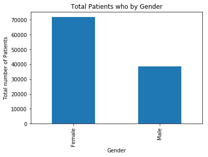

```python
# A bar graph showing Total Patients by Gender

df_Gender.plot(kind="bar", title="test")
plt.title('Total Patients who by Gender')
plt.xlabel('Gender')
plt.ylabel('Total number of Patients')
```

#### We have more of Female Patients than Male

```python
# Creating a new column for different age groups
#Children: 0-19 years , Young Adult: 20-39 years  , Adult: 40-59 years  ,  Aged: 60+

conditions = [
    (df['Age'] < 20),
    (df['Age'] >= 20) & (df['Age'] < 40),
    (df['Age'] >= 40) & (df['Age'] < 60),
    (df['Age'] >= 60)
]

values = ['Children', 'Young Adult', 'Adult', 'Aged']

df['Age Group'] = np.select(conditions, values)

df.head()
```

|  | PatientId | AppointmentID | Gender | ScheduledDay | AppointmentDay | Age | Neighbourhood | Scholarship | Hipertension | Diabetes | Alcoholism | Handcap | SMS_received | No-show | Age Group |
| --- | --- | --- | --- | --- | --- | --- | --- | --- | --- | --- | --- | --- | --- | --- | --- |
| 0 | 2.987250e+13 | 5642903 | Female | 2016-04-29 18:38:08+00:00 | 2016-04-29 00:00:00+00:00 | 62 | JARDIM DA PENHA | Not enrolled | Hypertensive | Not Diabetics | Not Alcoholic | 0 | Not Received | Showed up | Aged |
| 1 | 5.589978e+14 | 5642503 | Male | 2016-04-29 16:08:27+00:00 | 2016-04-29 00:00:00+00:00 | 56 | JARDIM DA PENHA | Not enrolled | Not Hypertensive | Not Diabetics | Not Alcoholic | 0 | Not Received | Showed up | Adult |
| 2 | 4.262962e+12 | 5642549 | Female | 2016-04-29 16:19:04+00:00 | 2016-04-29 00:00:00+00:00 | 62 | MATA DA PRAIA | Not enrolled | Not Hypertensive | Not Diabetics | Not Alcoholic | 0 | Not Received | Showed up | Aged |
| 3 | 8.679512e+11 | 5642828 | Female | 2016-04-29 17:29:31+00:00 | 2016-04-29 00:00:00+00:00 | 8 | PONTAL DE CAMBURI | Not enrolled | Not Hypertensive | Not Diabetics | Not Alcoholic | 0 | Not Received | Showed up | Children |
| 4 | 8.841186e+12 | 5642494 | Female | 2016-04-29 16:07:23+00:00 | 2016-04-29 00:00:00+00:00 | 56 | JARDIM DA PENHA | Not enrolled | Hypertensive | Diabetics | Not Alcoholic | 0 | Not Received | Showed up | Adult |

```python
# Total count of Patients by Age Group

df_Age_Group = df.groupby('Age Group')['PatientId'].count()
df_Age_Group
```

```
Age Group
Adult          30072
Aged           21173
Children       30412
Young Adult    28870
Name: PatientId, dtype: int64
```

```
Text(0,0.5,'Total Number of Patients')
```

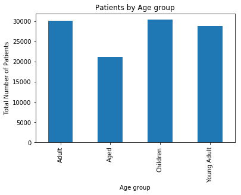

```python
# Plotting a bar graph to visualise Patients by Age group

df_Age_Group.plot(kind="bar", title="test")
plt.title('Patients by Age group')
plt.xlabel('Age group')
plt.ylabel('Total Number of Patients')
```

#### This shows that we have more of Children (0-19 years) and Adult (40 - 59 years) as patients

### Question 2: How many patients showed up for their appointments compared to those who failed to show up?

```python
#Total number of Patients who showed up for their appointments compared to those who failed to show up

df_Appointment_Response = df.groupby('No-show')['PatientId'].count()
df_Appointment_Response
```

```
No-show
No Show      22319
Showed up    88208
Name: PatientId, dtype: int64
```

```python
# Visualising above result as a percentage of Total

def percent(value):
    percent = round(df[value].value_counts()/len(df)*100)
    return percent
```

```
Text(0.5,1,'% of Patients who showed up for their appointments VERSUS those who failed to')
```

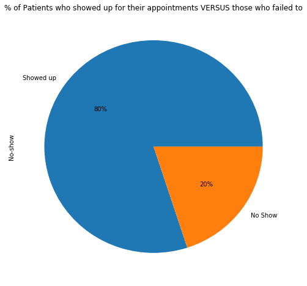

```python
value = percent('No-show')

value.plot(kind = 'pie',labels = ['Showed up','No Show'], autopct = '%1.0f%%', figsize = (8,8))
plt.title("% of Patients who showed up for their appointments VERSUS those who failed to")
```

##### Above is the Graphical representation of Patients who showed up for their appointments compared to those who failed to show up

#### It can be seen that patients who showed up for their appointment (88,208 in total) are more than patients who failed to show up (22,319). In summary, approximately 80% of the patients showed up for their appointments.

### Question 3: What Gender of the patients showed up for appointment the most?

```python
# Filtering down to patient that showed up for their appointments

df_Show = df[df['No-show'] == "Showed up"]
df_Show.head()
```

|  | PatientId | AppointmentID | Gender | ScheduledDay | AppointmentDay | Age | Neighbourhood | Scholarship | Hipertension | Diabetes | Alcoholism | Handcap | SMS_received | No-show | Age Group |
| --- | --- | --- | --- | --- | --- | --- | --- | --- | --- | --- | --- | --- | --- | --- | --- |
| 0 | 2.987250e+13 | 5642903 | Female | 2016-04-29 18:38:08+00:00 | 2016-04-29 00:00:00+00:00 | 62 | JARDIM DA PENHA | Not enrolled | Hypertensive | Not Diabetics | Not Alcoholic | 0 | Not Received | Showed up | Aged |
| 1 | 5.589978e+14 | 5642503 | Male | 2016-04-29 16:08:27+00:00 | 2016-04-29 00:00:00+00:00 | 56 | JARDIM DA PENHA | Not enrolled | Not Hypertensive | Not Diabetics | Not Alcoholic | 0 | Not Received | Showed up | Adult |
| 2 | 4.262962e+12 | 5642549 | Female | 2016-04-29 16:19:04+00:00 | 2016-04-29 00:00:00+00:00 | 62 | MATA DA PRAIA | Not enrolled | Not Hypertensive | Not Diabetics | Not Alcoholic | 0 | Not Received | Showed up | Aged |
| 3 | 8.679512e+11 | 5642828 | Female | 2016-04-29 17:29:31+00:00 | 2016-04-29 00:00:00+00:00 | 8 | PONTAL DE CAMBURI | Not enrolled | Not Hypertensive | Not Diabetics | Not Alcoholic | 0 | Not Received | Showed up | Children |
| 4 | 8.841186e+12 | 5642494 | Female | 2016-04-29 16:07:23+00:00 | 2016-04-29 00:00:00+00:00 | 56 | JARDIM DA PENHA | Not enrolled | Hypertensive | Diabetics | Not Alcoholic | 0 | Not Received | Showed up | Adult |

```python
# Total number of patients who showed up for their appointment by Gender

df_Show_Gender = df_Show.groupby('Gender')['PatientId'].count()
df_Show_Gender
```

```
Gender
Female    57246
Male      30962
Name: PatientId, dtype: int64
```

```
Text(0,0.5,'Total Number of Patients')
```

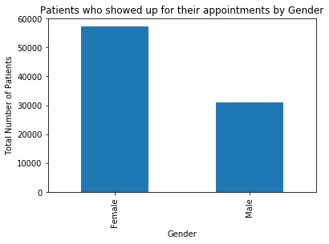

```python
# Plotting a bar graph to visualise Patients who showed up for their appointment by gender

df_Show_Gender.plot(kind="bar", title="test")
plt.title('Patients who showed up for their appointments by Gender')
plt.xlabel('Gender')
plt.ylabel('Total Number of Patients')
```

#### Most of the patients who showed up for their appointments are Females

### Question 4: What age category shows up the most for their appointments?

```python
# Patients who showed up for their appointments by their Age Category

df_age_show = df_Show.groupby('Age Group')['PatientId'].count()
df_age_show
```

```
Age Group
Adult          24416
Aged           17931
Children       23671
Young Adult    22190
Name: PatientId, dtype: int64
```

```
Text(0,0.5,'Total Number of Patients')
```

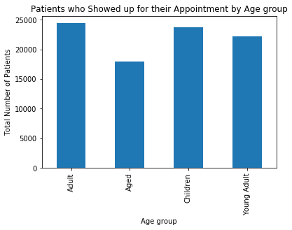

```python
# Plotting a bar graph to visualise Patients who showed up for their appointment by Age group

df_age_show.plot(kind="bar", title="test")
plt.title('Patients who Showed up for their Appointment by Age group')
plt.xlabel('Age group')
plt.ylabel('Total Number of Patients')
```

#### More of Adult Patients (40 - 59 years) and Children (0 - 20 years) showed up the most for their appointments

#### Question 5: How many of the patients who showed up for their appointments suffer from Hipertension, Diabetes and Alcoholism

```python
# Diabetics Patient that showed up for their appointments

df_Show_Diabetics = df_Show['Diabetes'].value_counts()
df_Show_Diabetics
```

```
Not Diabetics    81695
Diabetics         6513
Name: Diabetes, dtype: int64
```

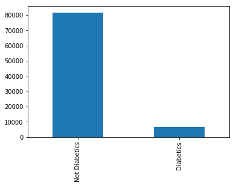

```python
# A bar graph showing Diabetics Patient that showed up for their appointments

df_Show['Diabetes'].value_counts().plot(kind = 'bar')
```

```python
# Hypertensive Patient that showed up for their appointments

df_Show_Hipertension = df_Show['Hipertension'].value_counts()
df_Show_Hipertension
```

```
Not Hypertensive    70179
Hypertensive        18029
Name: Hipertension, dtype: int64
```

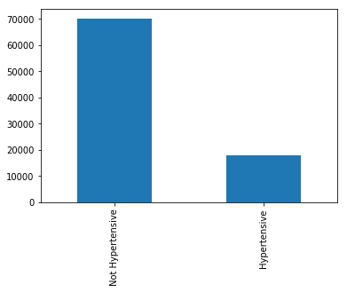

```python
## A bar graph showing Hypertensive Patients that showed up for their appointments

df_Show['Hipertension'].value_counts().plot(kind = 'bar')
```

```python
# Alcoholic Patient that showed up for their appointments

df_Show_Alcoholism = df_Show['Alcoholism'].value_counts()
df_Show_Alcoholism
```

```
Not Alcoholic    85525
Alcoholic         2683
Name: Alcoholism, dtype: int64
```

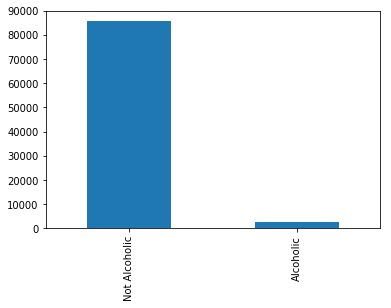

```python
# A bar graph showing Alcoholic Patient that showed up for their appointments

df_Show['Alcoholism'].value_counts().plot(kind = 'bar')
```

#### There are 6513 Diabetics Patients, 18029 Hypertensive Patients and 2683 Alcoholic Patients

### Question 6: How many Patients got enrolled in the government scholarship showed up for their appointments?

```python
# Patients who enrolled for the scholarship that showed up for their appointments

df_Show_Scholarship = df_Show['Scholarship'].value_counts()
df_Show_Scholarship
```

```
Not enrolled    79925
Enrolled         8283
Name: Scholarship, dtype: int64
```

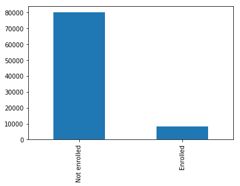

```python
# A bar graph showing Patients who enrolled for the scholarship that showed up for their appointments

df_Show['Scholarship'].value_counts().plot(kind = 'bar')
```

### Question 7: How many Patients who got SMS reminder message showed up for their appointments compared to those who did not get the reminder?

```python
# Patients who got SMS reminder message and those who do not but still showed up for their appointments

df_Show_SMS_received = df_Show['SMS_received'].value_counts()
df_Show_SMS_received
```

```
Not Received    62510
Received        25698
Name: SMS_received, dtype: int64
```

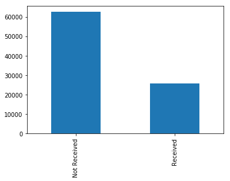

```python
# Bar graph showing Patients who got SMS reminder message and those who do not but still showed up for their appointments

df_Show['SMS_received'].value_counts().plot(kind = 'bar')
```

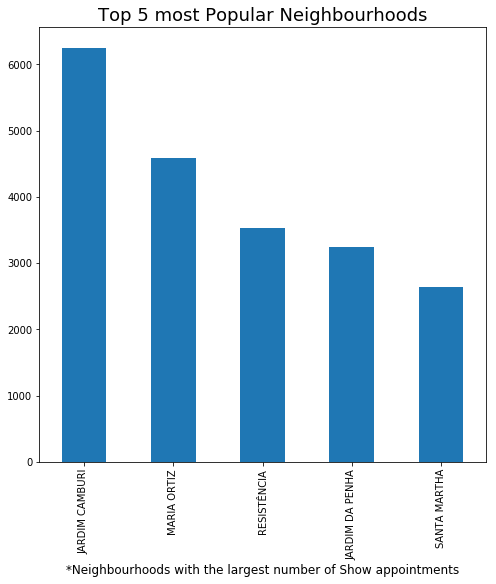

```python
# for the top 5 most popular Neighbourhood for the Hospitals

df_Show.Neighbourhood.value_counts()[:5].plot(kind='bar', figsize=(8, 8))
plt.title("Top 5 most Popular Neighbourhoods", fontsize=18)
plt.xlabel("*Neighbourhoods with the largest number of Show appointments", fontsize=12)
plt.ylabel("");
```

#### The above graphs shows the top 5 most popular Neighbourhood.

```python
# Filtering down to patients who did not show up for their appointments

df_No_Show = df[df['No-show'] == "No Show"]
df_No_Show.head()
```

|  | PatientId | AppointmentID | Gender | ScheduledDay | AppointmentDay | Age | Neighbourhood | Scholarship | Hipertension | Diabetes | Alcoholism | Handcap | SMS_received | No-show | Age Group |
| --- | --- | --- | --- | --- | --- | --- | --- | --- | --- | --- | --- | --- | --- | --- | --- |
| 6 | 7.336882e+14 | 5630279 | Female | 2016-04-27 15:05:12+00:00 | 2016-04-29 00:00:00+00:00 | 23 | GOIABEIRAS | Not enrolled | Not Hypertensive | Not Diabetics | Not Alcoholic | 0 | Not Received | No Show | Young Adult |
| 7 | 3.449833e+12 | 5630575 | Female | 2016-04-27 15:39:58+00:00 | 2016-04-29 00:00:00+00:00 | 39 | GOIABEIRAS | Not enrolled | Not Hypertensive | Not Diabetics | Not Alcoholic | 0 | Not Received | No Show | Young Adult |
| 11 | 7.542951e+12 | 5620163 | Male | 2016-04-26 08:44:12+00:00 | 2016-04-29 00:00:00+00:00 | 29 | NOVA PALESTINA | Not enrolled | Not Hypertensive | Not Diabetics | Not Alcoholic | 0 | Received | No Show | Young Adult |
| 17 | 1.479497e+13 | 5633460 | Female | 2016-04-28 09:28:57+00:00 | 2016-04-29 00:00:00+00:00 | 40 | CONQUISTA | Enrolled | Not Hypertensive | Not Diabetics | Not Alcoholic | 0 | Not Received | No Show | Adult |
| 20 | 6.222575e+14 | 5626083 | Female | 2016-04-27 07:51:14+00:00 | 2016-04-29 00:00:00+00:00 | 30 | NOVA PALESTINA | Not enrolled | Not Hypertensive | Not Diabetics | Not Alcoholic | 0 | Not Received | No Show | Young Adult |

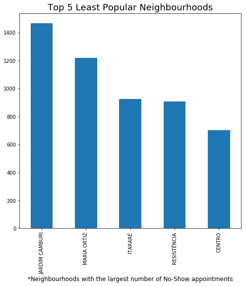

```python
# Bar graph showing the least popular Neighbourhoods for the different hospitals

df_No_Show.Neighbourhood.value_counts()[:5].plot(kind='bar', figsize=(8, 8))
plt.title("Top 5 Least Popular Neighbourhoods", fontsize=18)
plt.xlabel("*Neighbourhoods with the largest number of No-Show appointments", fontsize=12)
plt.ylabel("");
```

## Conclusions

#### 3) There are also more Female patients than male, a research can be made to find out the cause of this, especially within the Neighbourhoods.

#### 4) These patients are mostly Children and Adults,the Hospital can also look into the cause if that.

#### 5) The analysis also showed that Hospitals in Jardim Camburi, Maria Oritz, Itarare, Resistencia and Centro Neighbourhood has the largest number of No - Show appointments. The reason for this should also be looked into.

#### Limitation: This data does not include the distance between patient's location and the Hospital, which is an important factor in identifying the reason for some patient's failure to show up for their appointments.

```python
from subprocess import call
call(['python', '-m', 'nbconvert', 'Investigate_a_Dataset.ipynb'])
```

```
0
```